# S371: Lab 4

Lab Instructor: Katya Baldina (baldina@iu.edu)

2023-09-13

# Announcement

HW2 is due Sep.14 (TOMORROW)!

Your first test is on Sep.20 1PM - Sep.21 11.59PM.

There will be a *lab review session* on Sep.20 11.30AM-12.45PM AT *BALLANTINE HALL 346*

*NO CLASS WITH PROF. SCHULTZ, BUT A LAB REVIEW SESSION WITH ME*

# HW1 Reflection

- Please, make graphs bigger
- Include computations by hand, and *make sure they are readable*
- Include calculations under problems, not at the end of the document
- Don’t submit two and more documents. I can miss them when I grade. Make sure all HW is in one single file.

# Today

- R Object: Data frames
- R Object: Variables in Data frames
- Tables in R
- Missing data
- HW 2 Guide

# Download these materials

- smdata.Rda
- gss.Rda

On Canvas (Modules section) or on the [lab website](https://katyalex.github.io/Lab-Materials.html).

# Comment in R

- Imagine you have written codes in R for the final project a week before the deadline
- How do you know what you were doing with the codes in R when you are writing the report the day before the deadline?
- Comments going along with the code in R can help you
- Whenever a line starts with a hashtag (#), R would skip that line
- So we can use this property to add notes for us to read later

```r
##This is example of a comment.
```

```r
This is not comment.
```

```
## Error: <text>:1:6: unexpected symbol
## 1: This is
##          ^
```

# R Object: Data Frame

- Data frame is a collection of variables
- Each column represents a variable
- Each row represents one observation

# R Object: Data Frame

Download smdata.Rda from the “Lab Materials” folder on Canvas

Load the data into R:

```r
load('smdata.Rda') ## Remember that your dataset should be in the same working directory as your R working directory (to check it, go to the Lab 2 materials)
```

Type command as follows:

```r
View(smdata)
```

The data would be displayed as a spreadsheet, similar to Excel spreadsheet

[figure not shown]

And you can see in your environment panel that *smdata* has 2809 observations and 9 variables:

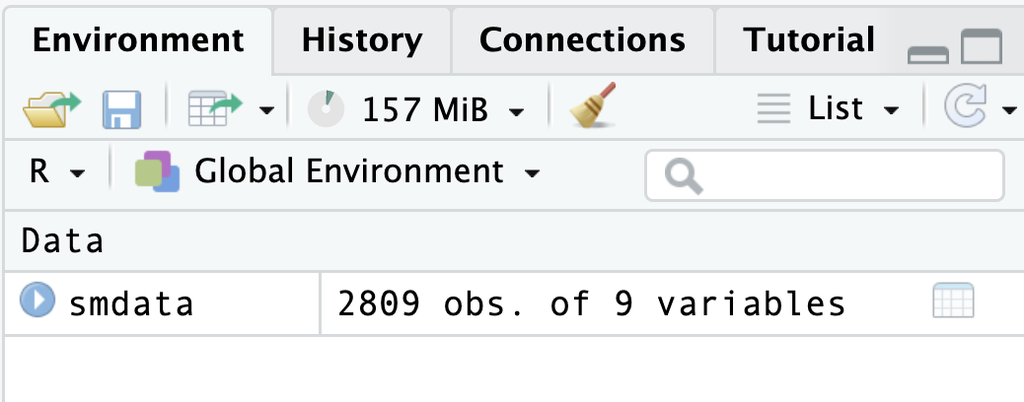

# R Object: Data Frame

How to understand what the data frame tells you?

|  | AGE | SNAPCHAT | INSTAGRM | FACEBOOK | TWITTER | TUMBLR | WHATSAPP | AGE2 | SM |
| --- | --- | --- | --- | --- | --- | --- | --- | --- | --- |
| 1 | 40 | NA | NA | NA | NA | NA | NA | 35-54 |  |
| 2 | 60 | NO | NO | NO | NO | NO | NO | 55+ | Neither one |
| 3 | 70 | NO | NO | NO | NO | NO | NO | 55+ | Neither one |
| 4 | 40 | NA | NA | NA | NA | NA | NA | 35-54 |  |
| 6 | 50 | NO | YES | NO | NO | NO | NO | 35-54 | Neither one |
| 7 | 50 | NA | NA | NA | NA | NA | NA | 35-54 |  |

For example, the second row represents one observation, and this person is 60 y.o., doesn’t use Instagram, Facebook, Twitter, WhatsApp, etc.

Each column represents one variable that varies across observations (in this case, person).

The value of `NA` represents missing data (i.e. there is no information for the person’s use of Snapchat or any other variable with NA)

# R Object: Data frame

When we apply the summary() command on the data frame, we get the summary for all the variables in the data frame.

```r
summary(smdata)
```

```
##       AGE         SNAPCHAT           INSTAGRM           FACEBOOK
##  Min.   :10.0   Length:2809        Length:2809        Length:2809
##  1st Qu.:30.0   Class :character   Class :character   Class :character
##  Median :40.0   Mode  :character   Mode  :character   Mode  :character
##  Mean   :44.5
##  3rd Qu.:60.0
##  Max.   :80.0
##    TWITTER             TUMBLR            WHATSAPP             AGE2
##  Length:2809        Length:2809        Length:2809        Length:2809
##  Class :character   Class :character   Class :character   Class :character
##  Mode  :character   Mode  :character   Mode  :character   Mode  :character
##
##
##
##       SM
##  Length:2809
##  Class :character
##  Mode  :character
##
##
##
```

If you put down an R object which is a vector within the parentheses, this function outputs the 5-number summary and the mean

If you put down an R object which is a data frame within the parentheses, this function outputs 5-number summary and the mean for all continuous variables and the number of observations for all categorical variables.

# R Object: Data frame

What if you want to obtain the summary statistics of only one variable?

Let’s look up the summary statistics for the *AGE*:

```r
summary(smdata$AGE)
```

```
##    Min. 1st Qu.  Median    Mean 3rd Qu.    Max.
##    10.0    30.0    40.0    44.5    60.0    80.0
```

1. Specify the name of the dataset
2. Dollar sign means *within the dataset*
3. Specify the name of the variable in the dataset

# Let’s practice

Please, load gss.Rda dataset into R and answer the following questions:

1. How many observations are there?
2. How many variables are there?
3. Run the summary command for the variable called age. What are the results (i.e. five-number summary and the mean)?

# Table in R

We learned how to summarize a quantitative (continuous) variable by obtaining the five-number summary and the mean.

How about qualitative (categorical) variable?

We can use `table()` command to show the distribution of a categorical variable:

```r
table(smdata$SNAPCHAT)
```

```
##
##   NO  YES
## 1037  308
```

# Table in R

Try to obtain the table for the variable AGE2 in smdata.

What are the numbers of people in each age group?

# Table in R

Try to obtain the table for the variable AGE2 in smdata.

What are the numbers of people in each age group?

```r
table(smdata$AGE2)
```

```
##
## 18-34 35-54   55+
##   737   970  1102
```

What if you want to make a table in proportions?

To do it we need `sum()` function!

# Table in R

In R you can combine functions together:

- `table(smdata$AGE2)` gives you the number of observations
- `sum(table(smdata$AGE2))` gives you total number of observations
- then you can ask R to divide each cell by the total number of observations:

```r
table(smdata$AGE2)/sum(table(smdata$AGE2))
```

```
##
##     18-34     35-54       55+
## 0.2623710 0.3453186 0.3923104
```

# Table in R

We can also make a bivariate table (cross-table of two variables)

For example, you want to see the number of people who use Snapchat by age group:

```r
table(smdata$SNAPCHAT, smdata$AGE2)
```

```
##
##       18-34 35-54 55+
##   NO    237   443 357
##   YES   216    74  18
```

# Table in R

Your turn: What are the numbers of people who use Twitter by age group?

# Table in R

Your turn: What are the numbers of people who use Twitter by age group?

```r
table(smdata$TWITTER, smdata$AGE2)
```

```
##
##       18-34 35-54 55+
##   NO    321   428 344
##   YES   132    89  31
```

# Missing Data: using Table in R

There is missing data in the variable SNAPCHAT

How does the `table()` command treat missing data?

```r
table(smdata$SNAPCHAT)
```

```
##
##   NO  YES
## 1037  308
```

Count the number of observations in the variable above and compare it with the total number of observations (hint: look at the environment panel to look up the total number of observations).

# Missing Data: using Table in R

There is missing data in the variable SNAPCHAT

How does the `table()` command treat missing data?

```r
table(smdata$SNAPCHAT)
```

```
##
##   NO  YES
## 1037  308
```

Count the number of observations in the variable above and compare it with the total number of observations (hint: look at the environment panel to look up the total number of observations).

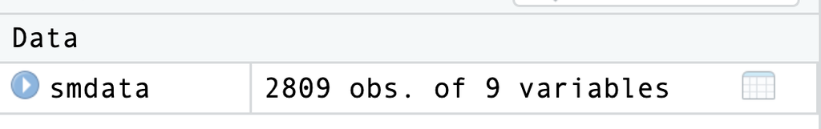

# Missing Data: using Table in R

Total number of observations in 2809 and number of observations in the table command is 1345 (1037+308). Therefore, there is

```r
2809-1345 #number of missing values in the SNAPCHAT variable
```

```
## [1] 1464
```

# Missing Data: `is.na()` command

`is.na()` command creates a vector of logicals with the same number of total observations as the original variable.

– Vector of logicals: takes on two values (TRUE/FALSE) and has the same number of observation displayed in the environment window.

TRUE: observation is missing

FALSE: observation is *not* missing

```r
head(is.na(smdata$SNAPCHAT)) #head() function shows you the first six observations in the vector or dataframe (to save the space)
```

```
## [1]  TRUE FALSE FALSE  TRUE FALSE  TRUE
```

# R Object

*R object*: it is the thing that you can store in your current R working environment (*note: all R objects will be gone once you close RStudio*)

You can store almost anything in R as an object:

• A number

• Characters

• A vector (a list of numbers/a list of characters)

• *Logicals (TRUE/FALSE)*

• Data frame (kind of like an Excel spreadsheet with numbers stored in columns and rows)

• and many others…

# Missing Data: `is.na()` command

But how do you know how many missing values are there????????!!?!??!!?!?

You can count manually…but…

```r
is.na(smdata$SNAPCHAT)
```

```
##    [1]  TRUE FALSE FALSE  TRUE FALSE  TRUE FALSE  TRUE FALSE FALSE  TRUE FALSE
##   [13] FALSE FALSE  TRUE  TRUE  TRUE FALSE  TRUE FALSE FALSE FALSE  TRUE FALSE
##   [25]  TRUE  TRUE FALSE FALSE FALSE FALSE FALSE FALSE  TRUE FALSE FALSE  TRUE
##   [37] FALSE  TRUE  TRUE  TRUE FALSE FALSE FALSE FALSE FALSE  TRUE FALSE FALSE
##   [49] FALSE  TRUE FALSE FALSE  TRUE FALSE FALSE FALSE FALSE  TRUE FALSE FALSE
##   [61]  TRUE FALSE  TRUE FALSE FALSE  TRUE  TRUE  TRUE  TRUE  TRUE  TRUE  TRUE
##   [73]  TRUE  TRUE  TRUE  TRUE FALSE FALSE  TRUE FALSE  TRUE  TRUE FALSE  TRUE
##   [85] FALSE  TRUE  TRUE  TRUE FALSE  TRUE  TRUE FALSE FALSE FALSE  TRUE FALSE
##   [97] FALSE FALSE FALSE  TRUE  TRUE  TRUE  TRUE  TRUE  TRUE  TRUE  TRUE FALSE
##  [109]  TRUE FALSE  TRUE  TRUE FALSE FALSE FALSE FALSE FALSE FALSE FALSE FALSE
##  [121]  TRUE FALSE  TRUE  TRUE FALSE FALSE  TRUE  TRUE  TRUE FALSE  TRUE FALSE
##  [133]  TRUE  TRUE FALSE  TRUE  TRUE  TRUE  TRUE  TRUE FALSE FALSE FALSE FALSE
##  [145]  TRUE FALSE  TRUE FALSE FALSE FALSE  TRUE FALSE  TRUE FALSE  TRUE FALSE
##  [157]  TRUE FALSE  TRUE  TRUE  TRUE  TRUE  TRUE FALSE FALSE FALSE  TRUE FALSE
##  [169] FALSE FALSE FALSE  TRUE  TRUE FALSE FALSE  TRUE FALSE  TRUE  TRUE FALSE
```

[output cut: 220 more lines]

# Missing Data: `is.na()` command

But how do you know how many missing values are there????????!!?!??!!?!?

You can count manually…but…don’t do it!!

Just make a table!

```r
table(is.na(smdata$SNAPCHAT))
```

```
##
## FALSE  TRUE
##  1345  1464
```

# HW2 Guide

There are two parts:

Part1: Question 1-6 Part2 (R part): Question 7-8

I will walk through question 7 and 8 with you today.

If you have questions about Part 1, feel free to ask me after the end of the lab.

You don’t need to load data frame in HW2.

# HW2 Guide

`par()` function: this line sets the parameters so that the graphs generated by codes after this line will be arranged horizontally (exactly three graphs line up horizontally)

`rnorm()` function: generates 10,000 observations with mean 10 and standard deviation of 2 at random, based on normal distribution.

# HW2 Guide

You need to describe what does line of code below the #ADD COMMENT HERE:

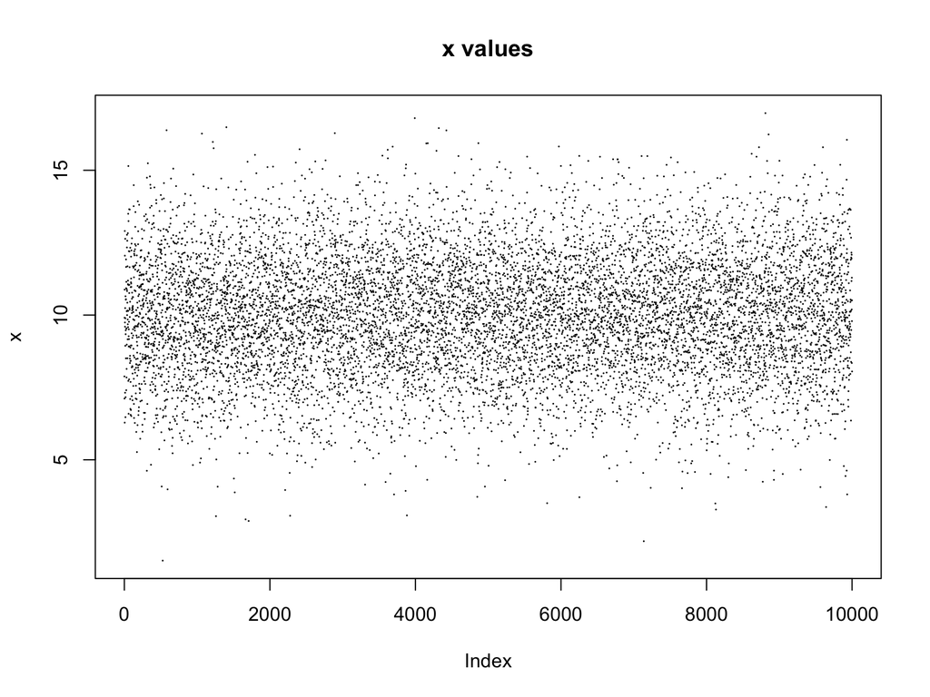

```r
x <- rnorm(10000,10,2)
# ADD COMMENT HERE
plot(x, main = 'x values', pch=16, cex=.2)
```

*Hint: run line starting with `plot()...` and then describe the output/graph generated by this line.*

You have to do the same for the following lines.

# HW2 Guide

`rchisq()` function: generates 10,000 observations with 10 degrees of freedom, and non-centrality parameter of 1 at random, based on a chi-square distribution (we will cover what a chi-square distribution is later in the class)

# HW2 Guide: Q8

*Hint: refer to Lab 3 slides. We have gone through these functions in Lab 3*

```r
#######################################################
# Part 2
#######################################################
# ADD COMMENT HERE
mean(x)
# ADD COMMENT HERE
sd(x)
# ADD COMMENT HERE
quantile(x,c(.0015,.025,.16,1-.16,1-.025,1-.0015))

# ADD COMMENT HERE
mean(y)
# ADD COMMENT HERE
sd(y)
# ADD COMMENT HERE
quantile(y,c(.0015,.025,.16,1-.16,1-.025,1-.0015))
```

# HW2 Guide: Q8

1. In a few sentences, describe the distributions of x and y. (2 points)

   *Hint: you need to describe if the distributions are skewed, normal, spread, etc.*